# Fiber Study: Statistical Analysis of Gene Expression Data for Correlation with Lipopolysaccharide Binding Protein (LBP) and Lecithin-Cholesterol Acyltransferase (LCAT) Activity

Brian

2023-05-18

## Introduction

This study explored the correlation between gene expression profiles and Lipopolysaccharide Binding Protein (LBP) and Lecithin-Cholesterol Acyltransferase (LCAT) activity. We employed edgeR and limma-voom transformation methodologies, two frequently used statistical tools for gene expression data analysis.

## Methods

### Data Preparation and Pre-processing

The raw gene expression data underwent pre-processing to remove background noise and normalize the values across different samples. This process ensures data quality and minimizes technical variation. We then filtered the data to remove low expression genes.

### edgeR Analysis

edgeR, a Bioconductor package, was used to identify differentially expressed genes. It leverages empirical Bayes estimation and exact tests based on the negative binomial distribution. edgeR was particularly suited for our analysis given its robustness in managing biological and experimental variability.

### limma-voom Transformation

Following the edgeR analysis, we applied the limma-voom transformation to our data. Limma-voom is a method for the analysis of gene expression data that specifically deals with RNA-sequencing (RNA-seq) data. It estimates the mean-variance relationship of the log-counts, generates a precision weight for each observation, and enters these into the limma empirical Bayes analysis pipeline. The voom transformation of limma ensures that the data meets the assumptions of standard linear statistical methods even when the original count data does not.

### Correlation Analysis with LBP and LCAT Activity

Post limma-voom transformation, we examined the correlation between the gene expression profiles and LBP and LCAT activity. Correlation coefficients were calculated for each gene with LBP and LCAT activity. The p-values were then adjusted for multiple testing to control the false discovery rate.

### For Manuscript Statistical Analysis

R software (version 4.2.2) was employed for the analysis of gene expression data, utilizing the edgeR package for differential expression and limma-voom for data transformation. Post-preprocessing and exclusion of lowly expressed genes, the transformed data were correlated with Lipopolysaccharide Binding Protein (LBP) and Lecithin-Cholesterol Acyltransferase (LCAT) activity. P-values were adjusted to control for the false discovery rate using the Benjamini-Hochberg method. The application of edgeR and limma-voom packages facilitated the identification of pertinent genes associated with LBP and LCAT activity.

## Packages

```r
if(!any(rownames(installed.packages()) == "pacman"))
        install.packages("pacman")
if(!any(rownames(installed.packages()) == 'HTSet'))
        devtools::install_github("zhuchcn/HTSet")

if (!require("BiocManager", quietly = TRUE))
    install.packages("BiocManager")
```

```r
pacman::p_load(here,
               tidyverse,
               rstatix,
               DT,
               ggpubr,
               readxl,
               reshape2,
                forcats,
               drc,
               rmcorr,
               cowplot,
               RColorBrewer,
               limma,
               edgeR,
               htmltools,
               openxlsx)
```

## Data Cleaning

```r
lcat <- readRDS(here("LCAT","data","LCAT_summary_filter_223B.rds"))
standard <- read_excel(here("LBP","standard","standard_lbp.xlsx"))
subject_characteristic <- read_csv(here("subject_characteristics","USANA Study Clinical Meta Data Sheet copy.csv")) |>
    mutate(sample = as.character(sample)) |>
    na.omit()

sample_sheet <- read_excel(here("subject_characteristics","P-00CL weighted USANA Walton (2020-05-26)-.xlsx"),
                           sheet = "Sample Sheet",
                           range  = "B21:E161") |>
    separate(`Your Sample ID`, into = c("subject", "code"), sep = 3) |>
    filter(!code %in% c("A","D","E")) |>
    rename(treatment = Group) |>
  mutate(treatment = case_when(
    treatment == "Treatment A" ~ "Prebiotic",
    treatment == "Treatment B" ~ "Placebo",
    TRUE ~ treatment
  ),
  timepoint = case_when(
      code == "B" | code == "F" ~ "pre",
      code == "C" | code == "G" ~ "post"
  ),
  subject = as.character(subject)) |>
    dplyr::select(!c("Sampling Date","Sample Type"))



plate_1 <- read_excel(here("LBP","raw","fslbp1-40.xlsx"),
                    sheet = "Sheet1",
                    range = "B46:N54",

) |>
        column_to_rownames(var = 1) |>
        as.matrix() |>
        melt(value.name = "absorbance",
             na.rm = TRUE)
plate_1$position <- paste0(plate_1$Var1, plate_1$Var2)


plate_2 <- read_excel(here("LBP","raw","fslbp41-80.xlsx"),
                    sheet = "Sheet1",
                    range = "B77:N85",

) |>
        column_to_rownames(var = 1) |>
        as.matrix() |>
        melt(value.name = "absorbance",
             na.rm = TRUE)
plate_2$position <- paste0(plate_2$Var1, plate_2$Var2)

plate_layout_1 <-  read_excel(here("LBP","plate_design","fslbp1-40_plate_design.xlsx"),
                    range = "A1:M9",
                    sheet = "Sheet1"

) |>
        column_to_rownames(var = 1) |>
        as.matrix() |>
        melt() |>
        rename(sample = "value") |>
        filter(!sample %in% "NA")
plate_layout_1$position <- paste0(plate_layout_1$Var1, plate_layout_1$Var2)


plate_layout_2 <-  read_excel(here("LBP","plate_design","fslbp41-80_plate_design.xlsx"),
                    range = "A1:M9",
                    sheet = "Sheet1"

) |>
        column_to_rownames(var = 1) |>
        as.matrix() |>
        melt() |>
        rename(sample = "value") |>
        filter(!sample %in% "NA")
plate_layout_2$position <- paste0(plate_layout_2$Var1, plate_layout_2$Var2)

plate_1 <- plate_1 |>
    left_join(plate_layout_1) |>
    mutate(sample = gsub(" ", "",sample))

plate_2 <- plate_2 |>
    left_join(plate_layout_2)
```

## LBP Standard: Four Parameter Logistic Regression

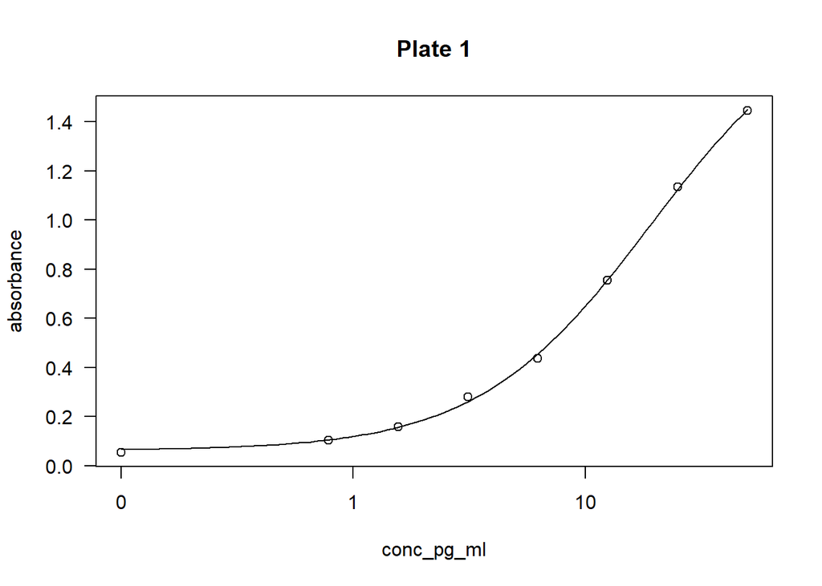

```r
plate_1_standard <- plate_1 |>
    left_join(standard)

model1<-drm(absorbance~conc_pg_ml,
             fct=LL.4(names=c("Slope", "Lower", "Upper", "ED50")),
data=plate_1_standard)
plot(model1,
     main = "Plate 1")
```

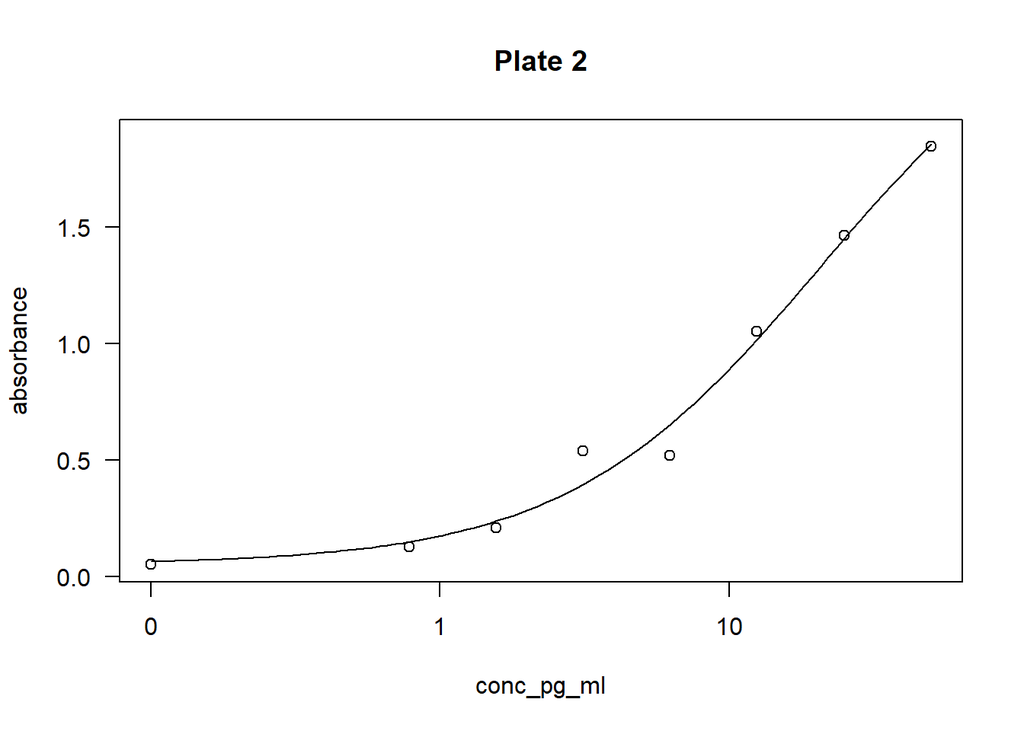

```r
plate_2_standard <- plate_2 |>
    left_join(standard)

model2<-drm(absorbance~conc_pg_ml,
             fct=LL.4(names=c("Slope", "Lower", "Upper", "ED50")),
data=plate_2_standard)
plot(model2,
     main = "Plate 2")
```

## Estimate Concentration

```r
### Plate 1
dilution_factor <- 800

plate_1_filter <- plate_1 |>
    filter(!grepl(pattern = "S", x = sample))

conc <-as.data.frame(ED(model1,plate_1_filter$absorbance,type="absolute",display=F))
conc_pg_ml <- conc$Estimate * dilution_factor

plate_1_filter <- cbind(plate_1_filter, conc_pg_ml)

### Plate 2

plate_2_filter <- plate_2 |>
    filter(!grepl(pattern = "S", x = sample))

conc <-as.data.frame(ED(model2,plate_2_filter$absorbance,type="absolute",display=F))
conc_pg_ml <- conc$Estimate * dilution_factor

plate_2_filter <- cbind(plate_2_filter, conc_pg_ml)

plate_combined <- plate_1_filter |>
    bind_rows(plate_2_filter) |>
    mutate(conc_ng_ml = conc_pg_ml/1000) |>
    left_join(subject_characteristic) |>
    mutate(treatment = ifelse(treatment=="A", "fiber", "placebo"),
           treatment = factor(treatment, levels = c("placebo","fiber")),
           timepoint = factor(timepoint, levels = c("pre", "post")))

plate_summary <- plate_combined |>
    group_by(subject, treatment, timepoint, gender) |>
    summarise(mean_conc_ng_ml = mean(conc_ng_ml),
              sd = sd(conc_ng_ml),
              cv = sd/mean_conc_ng_ml*100) |>
    mutate(subject = as.factor(subject))

plate_mean_lbp <- plate_combined |>
    group_by(subject, treatment, timepoint, `timepoint coded`) |>
    summarise(mean_conc_ng_ml = mean(conc_ng_ml)) |>
    mutate(subject = as.character(subject)) |>
    dplyr::select(!"timepoint coded") |>
    mutate(treatment = ifelse(treatment == "fiber","Prebiotic","Placebo")) |>
    left_join(sample_sheet)

lcat_summary <- lcat |>
    dplyr::select(subject, treatment, timepoint, norm.LCAT.ratio) |>
    mutate(subject = as.character(subject),
           treatment = ifelse(treatment == "fiber","Prebiotic","Placebo")) |>
    left_join(sample_sheet)
```

## LBP and Genes

### Data Clean Up

```
## [1] 2067  140
```

### LBP and Genes repeated measure correlation

```r
LBP <- log(genes_full$mean_conc_ng_ml)
# Extract the columns of interest
data_subset <- genes_full[, 6:1865]
# Assuming 'subject' is the name of your grouping variable
group_id <- as.factor(genes_full$subject)

# Add the grouping variable and the repeated measures variable to the data subset
data_subset <- cbind(group_id = group_id, LBP = LBP, data_subset)



# List to store the results
results_list <- list()

# Loop to perform rmcorr for each variable
for(i in 3:(ncol(data_subset))) {
    results <- rmcorr(dataset = data_subset,
                      participant = "group_id",
                      measure1 = "LBP",
                      measure2 = names(data_subset)[i])
    results_list[[names(data_subset)[i]]] <- results
}


# Convert list to data frame
results_df <- results_list %>%
  purrr::map_dfr(function(x) {
    tibble(
      Rmcorr = x$r,
      CI_lower = x$CI[1],
      CI_upper = x$CI[2],
      p_value = x$p,
    padj = p.adjust(p_value, method = "BH"),
    sig = insight::format_p(padj, name = NULL, stars_only = TRUE))
  }, .id = "letter")

results_df <- results_df |>
    mutate(padj = p.adjust(p_value, method = "BH"),
           sig = insight::format_p(padj, name = NULL, stars_only = TRUE)) |>
    left_join(gene_name) |>
    relocate(enzyme)
datatable(results_df) |>
    formatRound(columns = c("Rmcorr","CI_lower","CI_upper","p_value","padj"), digits = 3)
```

|  | enzyme | letter | Rmcorr | CI_lower | CI_upper | p_value | padj | sig |
| --- | --- | --- | --- | --- | --- | --- | --- | --- |
| 1 | aminoglycoside 6'-N-acetyltransferase I | aac6-I | -0.120458621072039 | -0.361319113672028 | 0.135471507795547 | 0.355110684526062 | 0.999526790454152 |  |
| 2 | aminoglycoside 3-N-acetyltransferase | aacC | -0.0376007882291499 | -0.286706798525832 | 0.216267715867254 | 0.773578031554239 | 0.999526790454152 |  |
| 3 | succinyl-CoA:acetate CoA-transferase | aarC | -0.240485427929176 | -0.464194887459856 | 0.0120660197942247 | 0.0619163159943307 | 0.999526790454152 |  |
| 4 | alanyl-tRNA synthetase | AARS | -0.124393240344613 | -0.364787097312233 | 0.131548220035219 | 0.339496906880445 | 0.999526790454152 |  |
| 5 | acyl-[acyl-carrier-protein]-phospholipid O-acyltransferase / long-chain-fatty-acid--[acyl-carrier-protein] ligase | aas | 0.0413748412456798 | -0.212661628424379 | 0.290172262930368 | 0.751548488230921 | 0.999526790454152 |  |
| 6 | acyl-[acyl-carrier-protein]-phospholipid O-acyltransferase / long-chain-fatty-acid--[acyl-carrier-protein] ligase | aas | 0.0413748412456798 | -0.212661628424379 | 0.290172262930368 | 0.751548488230921 | 0.999526790454152 |  |
| 7 | leucyl/phenylalanyl-tRNA---protein transferase | aat | -0.00558924820592921 | -0.257048194796716 | 0.24657854728988 | 0.965900308806386 | 0.999526790454152 |  |
| 8 | iron complex transport system ATP-binding protein | ABC.FEV.A | 0.0474478078799194 | -0.206844378502466 | 0.295735003897051 | 0.71651720913881 | 0.999526790454152 |  |
| 9 | polar amino acid transport system ATP-binding protein | ABC.PA.A | -0.10633710822068 | -0.348817257358902 | 0.149486565460507 | 0.414698027518432 | 0.999526790454152 |  |
| 10 | vitamin B12 transport system ATP-binding protein | ABC.VB12.A | 0.016682752852273 | -0.236129983116956 | 0.267380210699712 | 0.898457818257025 | 0.999526790454152 |  |

[output cut: 2057 more lines]

```r
sum(results_df$p_value < 0.05)
```

```
## [1] 22
```

```r
sum(results_df$padj < 0.05)
```

```
## [1] 0
```

```r
results_df_LBP <- results_df
```

> Our statistical analysis identified 22 genes that demonstrated a significant correlation with LBP based on the unadjusted p-values (p<0.05). However, following the adjustment for multiple testing using the Benjamini-Hochberg method, none of these correlations remained statistically significant. This result emphasizes the importance of multiple testing correction in high-throughput gene expression studies to control the false discovery rate and ensure robust findings. Further research is needed to uncover potential genetic correlates of LBP activity.

## LBP Activity and Gene Barplot

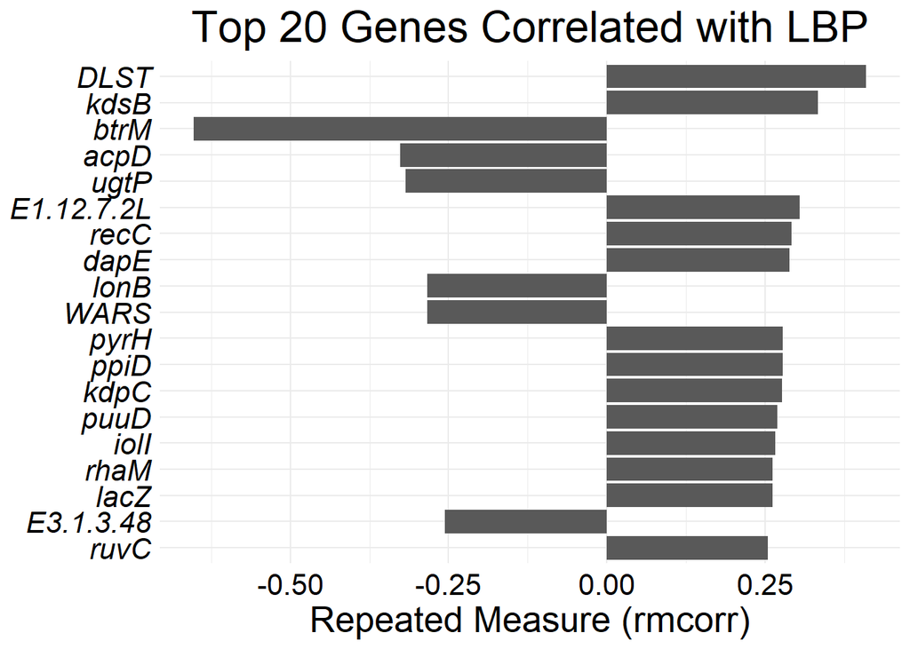

```r
# Select the top 20 absolute Rmcorr
top_results_df_LBP <- results_df %>%
    mutate(abs_Rmcorr = abs(Rmcorr)) %>%
    top_n(20, abs_Rmcorr)

# Get a palette of 9 colors
color_palette <- brewer.pal(9, "Set1")



# Create the bar plot
top20_LBP_gene_plot <- ggplot(top_results_df_LBP, aes(x = reorder(letter, abs_Rmcorr), y = Rmcorr)) +
    geom_bar(stat = "identity") +
    coord_flip() +
    labs(x = NULL, y = "Repeated Measure (rmcorr)",title = "Top 20 Genes Correlated with LBP") +
    theme_minimal() +
    theme(
          plot.title = element_text(hjust = 0.5, color = "black"),
          text = element_text(size = 20, color = "black"),
          axis.text = element_text(color = "black"),
          axis.title = element_text(color = "black"),
          legend.text = element_text(color = "black"),
          legend.title = element_text(color = "black")) +
    guides(fill = guide_legend(nrow = 2)) +
  theme(axis.text.y = element_text(face = "italic"))

print(top20_LBP_gene_plot)
```

```r
ggsave(top20_LBP_gene_plot, filename = here("figures","LBP_gene_corr.tiff"),
       dpi= 300,
       height = 8,
       width = 12,
       bg = "white")
```

## LCAT Activity and Genes repeated measure correlation

```r
genes_full <- lcat_summary |>
    mutate(subject = as.character(subject)) |>
    left_join(genes_wide) |>
    ungroup() |>
    dplyr::select(-1)
```

```r
LCAT <- genes_full$norm.LCAT.ratio
# Extract the columns of interest
data_subset <- genes_full[, 6:1865]
# Assuming 'subject' is the name of your grouping variable
group_id <- as.factor(genes_full$subject)

# Add the grouping variable and the repeated measures variable to the data subset
data_subset <- cbind(group_id = group_id, LCAT = LCAT, data_subset)



# List to store the results
results_list <- list()

# Loop to perform rmcorr for each variable
for(i in 3:(ncol(data_subset))) {
    results <- rmcorr(dataset = data_subset,
                      participant = "group_id",
                      measure1 = "LCAT",
                      measure2 = names(data_subset)[i])
    results_list[[names(data_subset)[i]]] <- results
}


# Convert list to data frame
results_df <- results_list %>%
  purrr::map_dfr(function(x) {
    tibble(
      Rmcorr = x$r,
      CI_lower = x$CI[1],
      CI_upper = x$CI[2],
      p_value = x$p,
    padj = p.adjust(p_value, method = "BH"),
    sig = insight::format_p(padj, name = NULL, stars_only = TRUE))
  }, .id = "letter")

results_df <- results_df |>
    mutate(padj = p.adjust(p_value, method = "BH"),
           sig = insight::format_p(padj, name = NULL, stars_only = TRUE)) |>
    left_join(gene_name) |>
    relocate(enzyme)
datatable(results_df) |>
    formatRound(columns = c("Rmcorr","CI_lower","CI_upper","p_value","padj"), digits = 3)
```

|  | enzyme | letter | Rmcorr | CI_lower | CI_upper | p_value | padj | sig |
| --- | --- | --- | --- | --- | --- | --- | --- | --- |
| 1 | aminoglycoside 6'-N-acetyltransferase I | aac6-I | -0.183369522879333 | -0.417838793837382 | 0.0740008090098212 | 0.160790351823445 | 0.568574247892791 |  |
| 2 | aminoglycoside 3-N-acetyltransferase | aacC | -0.220084596063266 | -0.44892136584691 | 0.0358432005815771 | 0.0910866142636515 | 0.544997156380038 |  |
| 3 | succinyl-CoA:acetate CoA-transferase | aarC | 0.0691018293399513 | -0.188123818012521 | 0.317456234671635 | 0.599841446160128 | 0.905266321001479 |  |
| 4 | alanyl-tRNA synthetase | AARS | -0.0736742884070888 | -0.321582907262582 | 0.183686775078811 | 0.575864909423203 | 0.8978279392516 |  |
| 5 | acyl-[acyl-carrier-protein]-phospholipid O-acyltransferase / long-chain-fatty-acid--[acyl-carrier-protein] ligase | aas | -0.113424041569682 | -0.35706485967974 | 0.144667246210335 | 0.388199919540827 | 0.812206805788457 |  |
| 6 | acyl-[acyl-carrier-protein]-phospholipid O-acyltransferase / long-chain-fatty-acid--[acyl-carrier-protein] ligase | aas | -0.113424041569682 | -0.35706485967974 | 0.144667246210335 | 0.388199919540827 | 0.812206805788457 |  |
| 7 | leucyl/phenylalanyl-tRNA---protein transferase | aat | 0.0976362474851646 | -0.160261703967187 | 0.343055822433336 | 0.457994207392216 | 0.849419702876728 |  |
| 8 | iron complex transport system ATP-binding protein | ABC.FEV.A | -0.128944970139345 | -0.370731079441552 | 0.129210378960275 | 0.326149361722634 | 0.758297266005124 |  |
| 9 | polar amino acid transport system ATP-binding protein | ABC.PA.A | -0.0684579680848515 | -0.316874389374609 | 0.188747768716793 | 0.60325268012961 | 0.905266321001479 |  |
| 10 | vitamin B12 transport system ATP-binding protein | ABC.VB12.A | -0.226199834845381 | -0.4540452128402 | 0.0294143615959604 | 0.0822316677469691 | 0.544997156380038 |  |

[output cut: 2057 more lines]

```r
sum(results_df$p_value < 0.05)
```

```
## [1] 44
```

```r
sum(results_df$padj < 0.05)
```

```
## [1] 0
```

```r
results_df_LCAT <- results_df
```

> Our statistical analysis identified 44 genes that demonstrated a significant correlation with LCAT Activity based on the unadjusted p-values (p<0.05). However, following the adjustment for multiple testing using the Benjamini-Hochberg method, none of these correlations remained statistically significant. This result emphasizes the importance of multiple testing correction in high-throughput gene expression studies to control the false discovery rate and ensure robust findings. Further research is needed to uncover potential genetic correlates of LBP activity.

## LCAT Activity and Gene Barplot

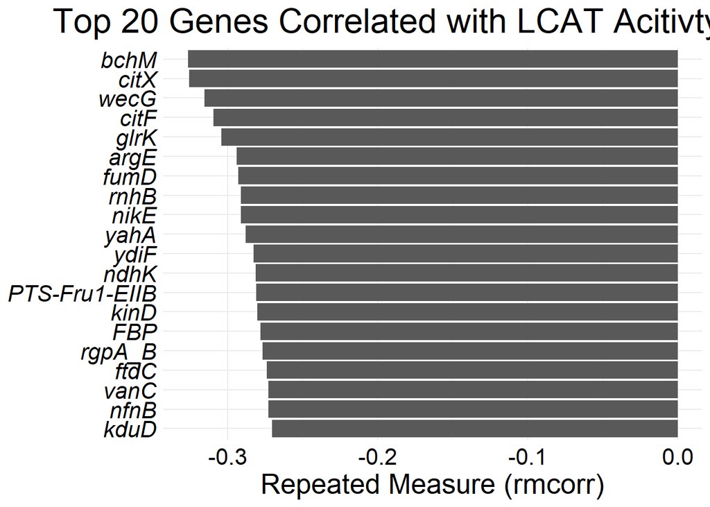

```r
# Select the top 20 absolute Rmcorr
top_results_df_LCAT <- results_df %>%
    mutate(abs_Rmcorr = abs(Rmcorr)) %>%
    top_n(20, abs_Rmcorr)

# Get a palette of 9 colors
color_palette <- brewer.pal(9, "Set1")



# Create the bar plot
top20_LCAT_gene_plot <- ggplot(top_results_df_LCAT, aes(x = reorder(letter, abs_Rmcorr), y = Rmcorr)) +
    geom_bar(stat = "identity") +
    coord_flip() +
    labs(x = NULL, y = "Repeated Measure (rmcorr)",title = "Top 20 Genes Correlated with LCAT Acitivty Index") +
    theme_minimal() +
    theme(
          plot.title = element_text(hjust = 0.5, color = "black"),
          text = element_text(size = 20, color = "black"),
          axis.text = element_text(color = "black"),
          axis.title = element_text(color = "black"),
          legend.text = element_text(color = "black"),
          legend.title = element_text(color = "black")) +
    guides(fill = guide_legend(nrow = 2)) +
  theme(axis.text.y = element_text(face = "italic"))

print(top20_LCAT_gene_plot)
```

```r
ggsave(top20_LCAT_gene_plot, filename = here("figures","LCAT_gene_corr.tiff"),
       dpi= 300,
       height = 8,
       width = 12,
       bg = "white")
```

## Combined Gene Correlation with LBP and LCAT

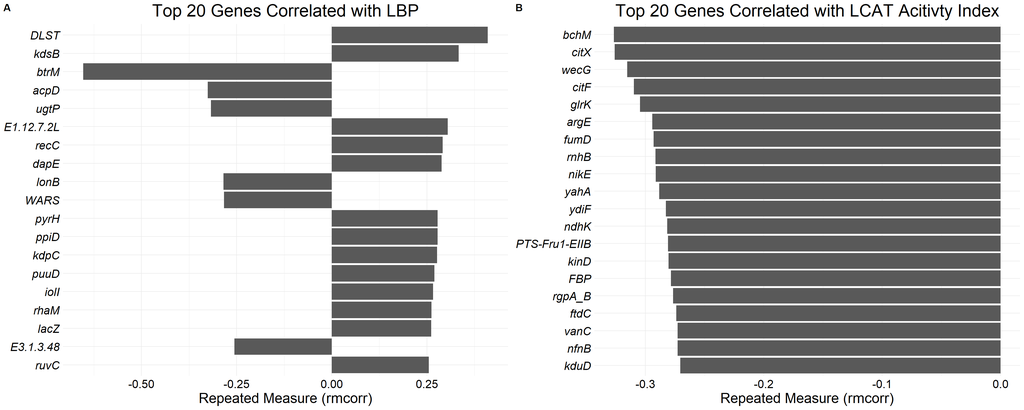

```r
# Combine the plots vertically
combined_plots <- plot_grid(top20_LBP_gene_plot, top20_LCAT_gene_plot, labels = c("A", "B"), ncol = 2)



print(combined_plots)
```

```r
ggsave(plot = combined_plots, filename = here("figures","LBP_LCAT_gene_plot.jpg"),
       dpi = 300,
       height = 6,
       width = 10,
       scale = 2,
       bg = "white")
```

### Output Excel LBP and LCAT corr with Gene to Supplemental file

```r
list_of_datasets <- list("LBP Rmcorr Genes" = results_df_LBP,
                         "LCAT Rmcorr Genes" = results_df_LCAT)
write.xlsx(list_of_datasets, file = here("output","LBP and LCAT Activity Corr Genes.xlsx"))
```

## Significance and direction (LBP)

```r
nrow(results_df_LBP)
```

```
## [1] 2067
```

```r
# Positive Rmcorr
pos_count <- sum(results_df_LBP$p_value[results_df_LBP$Rmcorr > 0] < 0.05)
pos_count
```

```
## [1] 14
```

```r
# Negative Rmcorr
neg_count <- sum(results_df_LBP$p_value[results_df_LBP$Rmcorr < 0] < 0.05)
neg_count
```

```
## [1] 8
```

> Out of 2067 total genes, there are 14 genes with statistically significant positive correlations and 8 genes with statistically significant negative correlations with LBP (P<0.05).

```r
nrow(results_df_LCAT)
```

```
## [1] 2067
```

```r
# Positive Rmcorr
pos_count <- sum(results_df_LCAT$p_value[results_df_LCAT$Rmcorr > 0] < 0.05)
pos_count
```

```
## [1] 2
```

```r
# Negative Rmcorr
neg_count <- sum(results_df_LCAT$p_value[results_df_LCAT$Rmcorr < 0] < 0.05)
neg_count
```

```
## [1] 42
```

## Summary

Future studies may validate these findings through laboratory experiments or explore the potential of these genes as therapeutic targets or biomarkers for conditions associated with LBP and LCAT activity.